# Environmental Micro

# Hypothesis 0

Kelly had asked to make sure that we were justified in averaging the two soil samples. Although everyone had two soil samples, the breakdown between swab and soil samples were not balanced between city and ses.

| city | ses | n_soil | n_swab |
| --- | --- | --- | --- |
| kisumu | low | 112 | 18 |
| kisumu | middle | 104 | 32 |
| nairobi | low | 65 | 59 |
| nairobi | middle | 28 | 102 |

I ran Mann-Whitney U Test’s to compare swab and soil samples within each neighborhood to test that the distributions are the same.

| path | kisumu low | kisumu middle | nairobi low | nairobi middle |
| --- | --- | --- | --- | --- |
| campylobacter | 0.85 [0.76-0.94]1 | 0.86 [0.79-0.93] | 0.31 [0.22-0.4] | 0.59 [0.47-0.7] |
| ecoli | 0.37 [0.24-0.5] | 0.39 [0.28-0.5] | 0.39 [0.29-0.49] | 0.57 [0.45-0.69] |
| listeria | 0.45 [0.31-0.59] | 0.43 [0.32-0.54] | 0.43 [0.33-0.54] | 0.46 [0.34-0.58] |
| salmonella | 0.43 [0.29-0.57] | 0.37 [0.26-0.47] | 0.36 [0.27-0.46] | 0.31 [0.2-0.42] |
| shigella | 0.01 [0-0.04] | 0.4 [0.29-0.52] | 0.36 [0.26-0.45] | 0.42 [0.3-0.54] |

1Red indicates significant difference bewteen swab and soil sample. Higher values indicate higher MPN in swab than soil samples.

About half of the soil sample types are significantly different between swab and soil sample.

# Hypothesis 1

Detection of Enterobacteriaceae in Kenyan households with young infants will differ by type of environmental material. Ho – no difference.

Descriptive statistics on the frequency and the detection rate/ prevalence (95%CI) of the pathogens per sample type.

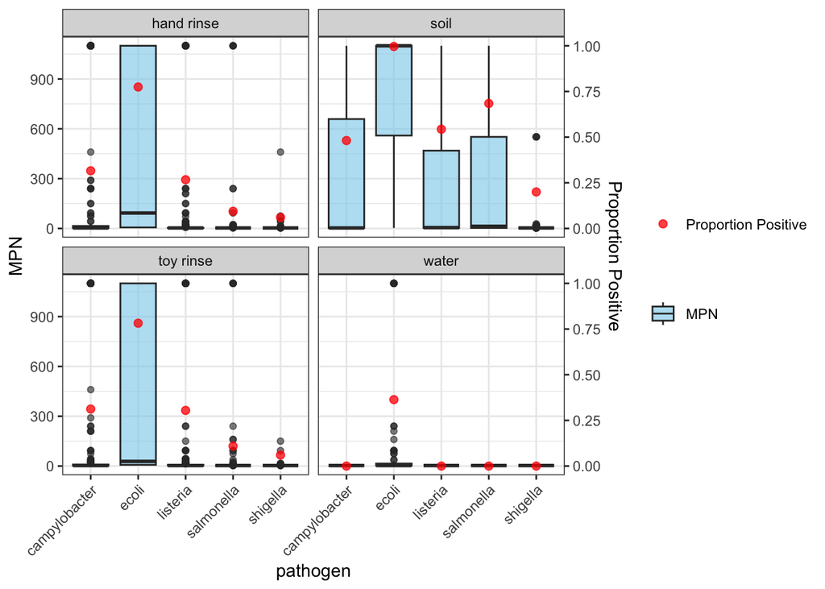

This plot captures the information requested from table 1 in the analysis request. The red dot indicates the proportion of samples with a positive mpn (>3).

# Hypothesis 2

Living in a middle income neighborhood with higher levels of improved water and sanitation coverage, lower crowding, and better overall road and drainage development is associated with lower levels of contamination on household soil, surfaces, hands, and in drinking water (Kisumu only) by Enterobacteriaceae than living in low-income informal settlements.

| Pathogen | Kisumu Soil | Kisumu Water | Kisumu Toy Rinse | Kisumu Hand Rinse | Nairobi Soil | Nairobi Water | Nairobi Toy Rinse | Nairobi Hand Rinse |
| --- | --- | --- | --- | --- | --- | --- | --- | --- |
| campylobacter | 0.41 [0.31-0.5]1 | 1 |  |  | 0.57 [0.47-0.66] | No Sample | 0.61 [0.52-0.71] | 0.61 [0.51-0.7] |
| ecoli | 0.52 [0.42-0.62] | 0.6 [0.51-0.7] | 0.53 [0.44-0.63] | 0.49 [0.39-0.59] | 0.49 [0.39-0.59] | No Sample | 0.56 [0.47-0.66] | 0.5 [0.4-0.6] |
| listeria | 0.54 [0.44-0.64] |  | 0.4 [0.3-0.49] | 0.45 [0.35-0.54] | 0.48 [0.38-0.58] | No Sample | 0.44 [0.34-0.54] | 0.46 [0.36-0.56] |
| salmonella | 0.54 [0.44-0.64] |  |  |  | 0.62 [0.53-0.72] | No Sample | 0.66 [0.57-0.75] | 0.59 [0.5-0.69] |
| shigella | 0.3 [0.21-0.39] |  | 0.51 [0.41-0.61] | 0.52 [0.42-0.61] | 0.49 [0.39-0.59] | No Sample | 0.44 [0.34-0.53] | 0.67 [0.58-0.76] |

1Red indicates higher median MPN in middle income neighborhood, Blue inidcates higher median MPN in low income.  
1Empty Cell indicates not enough positive samples to run test

From these results, we can say that the is a significantly higher median mpn in low income Nairobi Toy Rinse and Hand rinse for Campylobacter and Salmonella, and a higher median mpn in middle income Nairobi for toy rinse for shigella. In Kisumu, listeria in toy rinse and shigella in soil had a significantly higher median in low income, with ecoli in water having a higher mpn in low income Kisumu.

# Hypothesis 3

Household contamination by Enterobacteriaceae across one or more fomites is associated with an increased risk of 14-day diarrhea incidence.

## 3a (Descriptive)

### Covaraite Table for Modeling

|  | Kisumu low (N=70) | Kisumu middle (N=74) | Nairobi low (N=67) | Nairobi middle (N=69) |
| --- | --- | --- | --- | --- |
| sanitation |  |  |  |  |
| sanitation_basic | 8 (11.4%) | 32 (43.2%) | 2 (3.0%) | 28 (40.6%) |
| sanitation_limited | 62 (88.6%) | 42 (56.8%) | 65 (97.0%) | 41 (59.4%) |
| water_source |  |  |  |  |
| water_basic | 45 (64.3%) | 22 (29.7%) | 64 (95.5%) | 12 (17.4%) |
| water_privatetap | 25 (35.7%) | 52 (70.3%) | 3 (4.5%) | 57 (82.6%) |
| adj_wealth_index |  |  |  |  |
| Mean (SD) | 2.95 (1.10) | 3.95 (2.32) | 1.76 (0.832) | 3.48 (1.83) |
| Median [Min, Max] | 3.04 [0, 6.54] | 3.61 [0, 10.0] | 1.66 [0.359, 4.44] | 2.81 [0.166, 8.04] |

### Prevelence of Diarreha

| city | SES | Prevelence of Diarrhea |
| --- | --- | --- |
| Kisumu | low | 0.25 |
| Kisumu | middle | 0.26 |
| Nairobi | low | 0.50 |
| Nairobi | middle | 0.28 |

Note that these numbers are slightly different then Blessings Paper due to a smaller number of infants (not all infants had micro data collected). Also note that this analysis is modeling prevalence of self reported diarrhea, i.e., coming from diarreha calendar.

## 3b (Modeling)

Due to the large number of variables of interest, we split up the analysis by pathogen. For each pathogen, we modeled the odds of diarrhea, using City, SES, and MPN for each sample type.

**Campylobacter**

```
----------

Values given in terms of odds ratios

----------
```

| Variable | Post Mean | Lower | Upper | Prob Dir |
| --- | --- | --- | --- | --- |
| cityNairobi | 2.065 | 0.987 | 4.321 | 0.973 |
| SESmiddle | 0.607 | 0.358 | 1.029 | 0.968 |
| hand_rinse_campylobacter | 1.000 | 0.999 | 1.001 | 0.720 |
| toy_rinse_campylobacter | 1.000 | 0.999 | 1.001 | 0.537 |
| soil_campylobacter | 1.000 | 0.999 | 1.001 | 0.752 |

**Ecoli**

```
----------

Values given in terms of odds ratios

----------
```

| Variable | Post Mean | Lower | Upper | Prob Dir |
| --- | --- | --- | --- | --- |
| cityNairobi | 1.689 | 0.818 | 3.488 | 0.922 |
| SESmiddle | 0.578 | 0.338 | 0.990 | 0.977 |
| hand_rinse_ecoli | 1.001 | 1.000 | 1.001 | 0.975 |
| toy_rinse_ecoli | 0.999 | 0.999 | 1.000 | 0.928 |
| soil_ecoli | 1.000 | 0.999 | 1.001 | 0.500 |

**Listeria**

```
----------

Values given in terms of odds ratios

----------
```

| Variable | Post Mean | Lower | Upper | Prob Dir |
| --- | --- | --- | --- | --- |
| cityNairobi | 1.963 | 1.070 | 3.603 | 0.985 |
| SESmiddle | 0.617 | 0.363 | 1.047 | 0.963 |
| hand_rinse_listeria | 0.999 | 0.998 | 1.000 | 0.908 |
| toy_rinse_listeria | 1.000 | 0.999 | 1.001 | 0.523 |
| soil_listeria | 1.000 | 0.999 | 1.001 | 0.612 |

**Salmonella**

```
----------

Values given in terms of odds ratios

----------
```

| Variable | Post Mean | Lower | Upper | Prob Dir |
| --- | --- | --- | --- | --- |
| cityNairobi | 1.980 | 1.135 | 3.454 | 0.992 |
| SESmiddle | 0.597 | 0.349 | 1.023 | 0.970 |
| hand_rinse_salmonella | 1.000 | 0.998 | 1.002 | 0.652 |
| toy_rinse_salmonella | 1.000 | 0.998 | 1.002 | 0.550 |
| soil_salmonella | 1.000 | 0.999 | 1.001 | 0.797 |

**Shigella**

```
----------

Values given in terms of odds ratios

----------
```

| Variable | Post Mean | Lower | Upper | Prob Dir |
| --- | --- | --- | --- | --- |
| cityNairobi | 1.778 | 1.039 | 3.041 | 0.982 |
| SESmiddle | 0.616 | 0.361 | 1.051 | 0.962 |
| hand_rinse_shigella | 1.028 | 0.998 | 1.058 | 0.966 |
| toy_rinse_shigella | 1.096 | 1.011 | 1.188 | 0.987 |
| soil_shigella | 0.988 | 0.976 | 0.999 | 0.981 |

For the most part, there was not a statistical or clinically meaningful effect of pathogen mpn on odds of diarrhea. Soil and toy rinse shigella did have a a significant effect. A unit increase in shigella toy rinse results in an increase in the odds of diarrhea of 10%, but a unit increase in shigella soil results in a decrease in the odds of diarrhea of 1%.

# Hypothesis 4a

Associations between environmental contamination and diarrhea incidence are modified by household access to basic improved water sources and basic sanitation facilities.

To address this hypothesis, we added all sample types for each pathogen, i.e., salmonella = salmonella hand rinse + salmonella toy rinse + … + salmonella soil. This reduced the number of variables in the model to help with estimation. We then looked at the interaction between pathogen values and water source and sanitation, while accounting for neighborhood and wealth index.

```
----------

Values given in terms of odds ratios

----------
```

| Variable | Post Mean | Lower | Upper | Prob Dir |
| --- | --- | --- | --- | --- |
| cityNairobi | 1.798 | 0.803 | 4.026 | 0.923 |
| SESmiddle | 0.877 | 0.417 | 1.843 | 0.636 |
| adj_wealth_index | 0.590 | 0.443 | 0.787 | 1.000 |
| campylobacter | 1.001 | 0.999 | 1.003 | 0.909 |
| ecoli | 0.999 | 0.998 | 1.001 | 0.804 |
| listeria | 1.001 | 0.999 | 1.003 | 0.761 |
| salmonella | 1.001 | 0.997 | 1.005 | 0.669 |
| shigella | 1.148 | 1.031 | 1.279 | 0.994 |
| water_sourcewater_privatetap | 3.228 | 0.801 | 13.008 | 0.950 |
| sanitationsanitation_limited | 3.293 | 0.375 | 28.952 | 0.859 |
| campylobacter:water_sourcewater_privatetap | 0.999 | 0.997 | 1.000 | 0.951 |
| ecoli:water_sourcewater_privatetap | 1.000 | 0.999 | 1.001 | 0.548 |
| listeria:water_sourcewater_privatetap | 1.000 | 0.998 | 1.001 | 0.660 |
| salmonella:water_sourcewater_privatetap | 1.000 | 0.998 | 1.002 | 0.551 |
| shigella:water_sourcewater_privatetap | 0.989 | 0.975 | 1.003 | 0.934 |
| campylobacter:sanitationsanitation_limited | 0.999 | 0.997 | 1.001 | 0.850 |
| ecoli:sanitationsanitation_limited | 1.001 | 1.000 | 1.002 | 0.891 |
| listeria:sanitationsanitation_limited | 0.999 | 0.997 | 1.001 | 0.851 |
| salmonella:sanitationsanitation_limited | 0.999 | 0.995 | 1.002 | 0.778 |
| shigella:sanitationsanitation_limited | 0.873 | 0.783 | 0.972 | 0.993 |

There is a lot going on in this table, but there are a few key takeaways. First, as noted in Blessing’s paper, adjusted wealth index is protective of diarrhea (for a unit increase in wealth index, the odds of diarrhea decrease by 41%). We also see that shigella does have a significant association with diarrhea, which corresponds with the earlier modeling. Water source does not seem to have an effect, but sanitation when interacted with shigella does (last row of the table). The interpretation of this is for those who have limited sanitation, a unit increase in shigella results in a 12% decrease in odds of diarrhea, as compared to those with basic sanitation. Curious that shigella is protective of diarrhea.

| Variable | BF favoring alternative | Interpretation |
| --- | --- | --- |
| city | 0.398 | Not worth more than a bare mention (in favor of exluding from the model |
| SES | 0.154 | Substantial (in favor of exluding from the model |
| adj_wealth_index | 117.977 | Decisive (in favor of keeping in the model) |
| campylobacter | 0.020 | Strong (in favor of exluding from the model |
| ecoli | 0.011 | Strong (in favor of exluding from the model |
| listeria | 0.011 | Strong (in favor of exluding from the model |
| salmonella | 0.011 | Strong (in favor of exluding from the model |
| shigella | 1.109 | Not worth more than a bare mention (in favor of keeping in the model) |
| water_source | 0.016 | Strong (in favor of exluding from the model |
| sanitation | 0.024 | Strong (in favor of exluding from the model |

This table summaries the evidence for keeping a variable in the model, i.e., does it help explain the outcome. Only adjusted wealth index does.